# Utilisation de l’IA pour apprendre le codage

[Retour à la page d’accueil](https://scortijo.github.io/2026_L3_R/)

Dans cette séance nous allons voir comment utiliser les outils d’intelligence artificielle générative pour aider à l’apprentissage au codage

# Les IA peuvent donner des réponses fausses

**ChatGPT (et les autres outils d’IA) va toujours donner une réponse, même si elle est fausse.** Il est difficile de faire la différence entre une réponse juste ou fausse car ChatGPT va répondre dans les deux cas en ayant l’air sûr de lui. Il peut même donner de fausses réferences quand on lui demande.

**Il est donc important de vérifier les réponses de ChatGPT!**

Ci-dessous nous allons voir quelques manières d’utiliser ChatGPT (ou d’autres outils d’IA) pour nous aider au codage.

# Compréhension d’un code

## Explication d’un code

Un bon moyen d’utiliser ChatGPT est pour expliquer un code que nous avons trouvé. Il peut arriver de trouver lors d’une recherche en ligne un code qui semble répondre à notre question mais de ne pas tout comprendre.

Comme exemple, prenons la solution d’un des exercices bonus de notre cours.  
La question de l’exercice était:  
**Filtrez les données pour garder les lignes pour lesquelles le background contient Col**

Et la réponse était (plusieurs réponses sont possibles):

```r
expt1_col_background <- filter(expt1, grepl("Col", background))
```

> Connectez vous maintenant à ChatGPT et demandez lui d’expliquer cette ligne de code. Je vous conseille d’être poli avec ChatGPT (bonjour, s’il vous plait, merci…), [il sera plus efficace](https://www.journaldugeek.com/2024/02/28/ia-soyez-gentil-avec-chatgpt-et-il-vous-le-rendra-bien/).

> Que pensez vous du résultat? Si besoin demandez lui d’expliquer plus en détail certaines parties du code ou de donner un résultat plus concis

# Obtention d’un code à partir d’une question

### Un cas simple

Demandons à ChatGPT de trouver le code pour un des exercices du cours.  
Voici la consigne de l’exercice:

**Sélectionnez les colonnes dont le titre finit par “bolt”**

> Quel code optenez-vous? Est-ce que cela corresponds à la solution du cours et aux fonctions que nous avons vu en cours?

Pour rappel, voici la solution proposée en cours, faisant appel à une des fonctions que nous avons vu:

```r
select(expt1, ends_with("bolt"))
```

> Essayez de modifier votre demande à ChatGPT en précisant que vous voulez utilisez tidyverse.

> Est-ce que la réponse ressemble plus à ce que nous avons vu en cours?

### Une demande plus complexe

Voyons maintenant une demande plus complexe. Voici une des questions de l’exam de l’année dernière

**Faites une figure représentant la distribution de `blade.length.mm` divisé par `total.leaf.length.mm` en fonction des conditions dans lesquelles les plantes ont poussé avec un graphique par background.**

**Aide: - Créez une nouvelle colonne (blade.ratio) avec le ratio de `blade.length.mm` et `total.leaf.length.mm` - Créez une nouvelle colonne (nommée par exemple `condition`) en concaténant `day.length`, `temperature` et `fluctuation` - Sélectionnez les background `Col` et `Ler` - Faites un boxplot du ratio de `blade.length.mm` et `total.leaf.length.mm` en fonction de la `condition`, en créant des facets en fonction du background**

La solution est:

```r
mutate(expt1, blade.ratio=blade.length.mm/total.leaf.length.mm) %>%
  unite("condition", day.length, temperature, fluctuation, sep=".") %>%
  filter(background%in%c("Col","Ler")) %>%
  ggplot(aes(x=condition, y=blade.ratio)) +
  geom_boxplot()+
  ylim(0,1) +
  facet_grid(.~background) +
  theme(axis.text.x=element_text(angle = 45))
```

> Demandez à ChatGPT de générer le code pour répondre à cette question sans include l’aide.

> Est-ce que le code de ChatGPT est similaire à la réponse attendue?

> Essayez de nouveau, cette fois en utilisant l’aide.

> Est-ce que le code de ChatGPT est similaire à la réponse attendue?

> A votre avis pourquoi ChatGPT trouve la réponse dans le deuxième cas et pas dans le premier?

## Passer de la question biologique au code

Afin d’utiliser ChatGPT pour générer efficement un code gardez les 3 principes suivant en tête:

Principe 1: **Soyez specifique**. ChatGPT ne peut pas lire vos pensées  
Principe 2: **Pensez au contexte** (nom des variable, ce que vous avez demandé avant etc)  
Principe 3: **Découpez une opération complexe en plusieurs étapes**

Aussi gardez en tête que ChatGPT ne donnera par forcement la même réponse à la même demande.

### Premier exemple.

Nous voulons effectuer le graphique suivant pour comparer le nombre de feuilles de rosettes et de feuilles caulines:

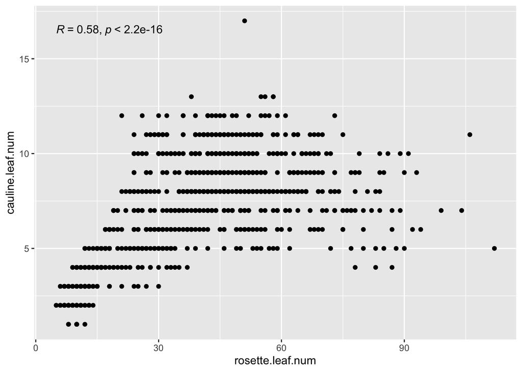

> Demandez à ChatGPT de générer un code pour comparer le nombre de feuilles de rosette et de feuilles caulines

> Est-ce que vous obtenez le résultat attendu?

> Retravaillez votre demande de manière à ce qu’elle soit plus spécifique et contienne le nom de vos variable afin de pouvoir utiliser le résultat directement.

### Deuxième exemple

Imaginons que nous voulons maintenant faire un graphiqe pour étudier l’effet de la fluctuation en température sur le ratio du nombre de feuilles de rosette et de feuilles cauline et ce uniquement pour les plantes vernalisées, en excluant le génotype vin3-4 FRI. Nous voulons un graphique pour chaque température et durée de jour.

> Demandez à ChatGPT le code pour obtenir le graphique ci-dessous. N’oubliez pas d’être précis et de décortiquer les différentes étapes.  
> Pour vous aider à réfléchir aux différentes étapes, voici le code permettant de répondre à cette question.

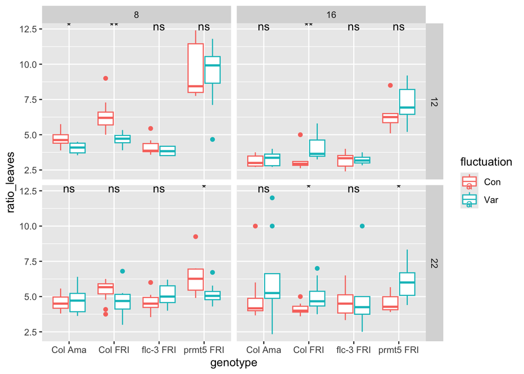

```r
mutate(expt1, ratio_leaves=rosette.leaf.num/cauline.leaf.num) %>%
  filter(vernalization=="V", genotype!="vin3-4 FRI") %>%
  ggplot(aes(x=genotype, y=ratio_leaves, col=fluctuation)) +
  geom_boxplot() +
  facet_grid(temperature~day.length) +
  stat_compare_means(label = "p.signif")
```

# Un outil combinant ChatGPT à vos données

Afin de vous aider au codage avec un outil qui combine ChatGPT à vos données vous pouvez utiliser le site [rtutor](https://rtutor.ai/)

[figure not shown]

#### Attention, tout tableau que vous mettez dans ce site n’est plus confidentiel. Ne l’utilisez pas pour des données sensibles ou non publiées!

# Autres outils d’IA pour l’aide au codage

- [Gemini (Google Bard)](https://gemini.google.com/?hl=fr)
- [Github Copilot](https://github.com/features/copilot). Cet outil peut [être utilisé dans Rstudio](https://docs.posit.co/ide/user/ide/guide/tools/copilot.html)

[Retour à la page d’accueil](https://scortijo.github.io/2026_L3_R/)